# Red Wine Quality Exploration by Tommy Siu

# Univariate Plots Section

```
## [1] 1599   12
```

```
##  [1] "fixed.acidity"        "volatile.acidity"     "citric.acid"
##  [4] "residual.sugar"       "chlorides"            "free.sulfur.dioxide"
##  [7] "total.sulfur.dioxide" "density"              "pH"
## [10] "sulphates"            "alcohol"              "quality"
```

```
## 'data.frame':    1599 obs. of  12 variables:
##  $ fixed.acidity       : num  7.4 7.8 7.8 11.2 7.4 7.4 7.9 7.3 7.8 7.5 ...
##  $ volatile.acidity    : num  0.7 0.88 0.76 0.28 0.7 0.66 0.6 0.65 0.58 0.5 ...
##  $ citric.acid         : num  0 0 0.04 0.56 0 0 0.06 0 0.02 0.36 ...
##  $ residual.sugar      : num  1.9 2.6 2.3 1.9 1.9 1.8 1.6 1.2 2 6.1 ...
##  $ chlorides           : num  0.076 0.098 0.092 0.075 0.076 0.075 0.069 0.065 0.073 0.071 ...
##  $ free.sulfur.dioxide : num  11 25 15 17 11 13 15 15 9 17 ...
##  $ total.sulfur.dioxide: num  34 67 54 60 34 40 59 21 18 102 ...
##  $ density             : num  0.998 0.997 0.997 0.998 0.998 ...
##  $ pH                  : num  3.51 3.2 3.26 3.16 3.51 3.51 3.3 3.39 3.36 3.35 ...
##  $ sulphates           : num  0.56 0.68 0.65 0.58 0.56 0.56 0.46 0.47 0.57 0.8 ...
##  $ alcohol             : num  9.4 9.8 9.8 9.8 9.4 9.4 9.4 10 9.5 10.5 ...
##  $ quality             : int  5 5 5 6 5 5 5 7 7 5 ...
```

```
##  fixed.acidity   volatile.acidity  citric.acid    residual.sugar
##  Min.   : 4.60   Min.   :0.1200   Min.   :0.000   Min.   : 0.900
##  1st Qu.: 7.10   1st Qu.:0.3900   1st Qu.:0.090   1st Qu.: 1.900
##  Median : 7.90   Median :0.5200   Median :0.260   Median : 2.200
##  Mean   : 8.32   Mean   :0.5278   Mean   :0.271   Mean   : 2.539
##  3rd Qu.: 9.20   3rd Qu.:0.6400   3rd Qu.:0.420   3rd Qu.: 2.600
##  Max.   :15.90   Max.   :1.5800   Max.   :1.000   Max.   :15.500
##    chlorides       free.sulfur.dioxide total.sulfur.dioxide
##  Min.   :0.01200   Min.   : 1.00       Min.   :  6.00
##  1st Qu.:0.07000   1st Qu.: 7.00       1st Qu.: 22.00
##  Median :0.07900   Median :14.00       Median : 38.00
##  Mean   :0.08747   Mean   :15.87       Mean   : 46.47
##  3rd Qu.:0.09000   3rd Qu.:21.00       3rd Qu.: 62.00
##  Max.   :0.61100   Max.   :72.00       Max.   :289.00
##     density             pH          sulphates         alcohol
##  Min.   :0.9901   Min.   :2.740   Min.   :0.3300   Min.   : 8.40
##  1st Qu.:0.9956   1st Qu.:3.210   1st Qu.:0.5500   1st Qu.: 9.50
##  Median :0.9968   Median :3.310   Median :0.6200   Median :10.20
##  Mean   :0.9967   Mean   :3.311   Mean   :0.6581   Mean   :10.42
##  3rd Qu.:0.9978   3rd Qu.:3.400   3rd Qu.:0.7300   3rd Qu.:11.10
##  Max.   :1.0037   Max.   :4.010   Max.   :2.0000   Max.   :14.90
##     quality
##  Min.   :3.000
##  1st Qu.:5.000
##  Median :6.000
##  Mean   :5.636
##  3rd Qu.:6.000
##  Max.   :8.000
```

Firstly, I notice that the values of residual sugar, chlorides and total sulfur dioxide have relatively large value ranges. Their maximum values are larger than their corresponding median and 3rd quantile values by a significant amount.

For the quality variable, the median value is 6, and the 1st quantile and 3rd quantile are 5 and 6 respectively. It means that there is at least 50% of samples having a quality of 5 or 6.

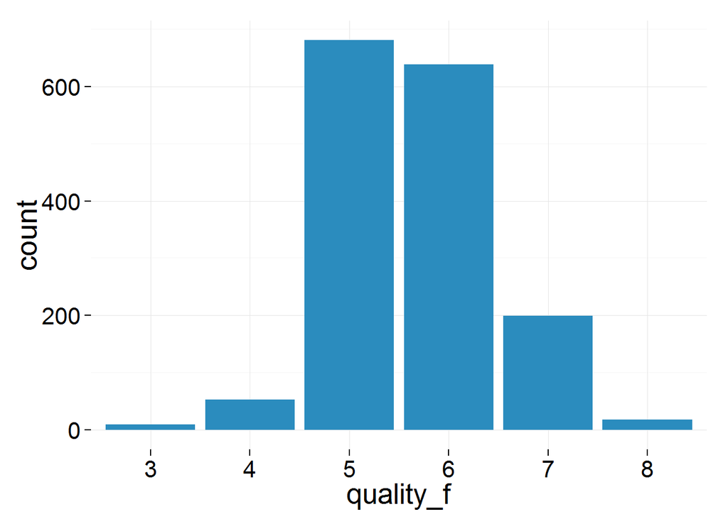

```
##
##   3   4   5   6   7   8
##  10  53 681 638 199  18
```

The quality histogram and the count table actually show that there is far more than 50% (around 80%) of samples having a quality of 5 or 6.

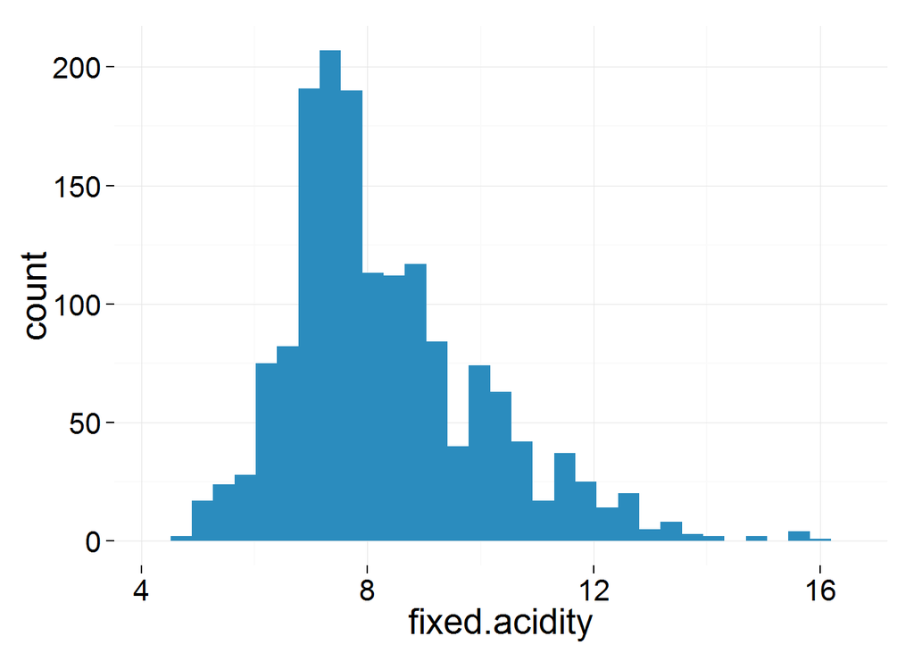

```
##
##  7.2  7.1  7.8  7.5    7  7.7  6.8  7.6  8.2  7.3  7.4  7.9    8  8.3  6.9
##   67   57   53   52   50   49   46   46   45   44   44   42   42   40   38
##  6.6  8.8  8.9  9.1  6.7  8.6  8.1  8.4    9  9.9  6.4  8.7   10  9.3 10.4
##   37   34   33   29   28   27   26   26   26   26   25   24   23   22   21
##  6.2  8.5 10.2  6.5  9.4  9.6  6.1  9.2  9.8  5.6  6.3  9.5 10.6    6 11.5
##   20   19   19   17   17   17   16   16   15   14   14   14   14   13   13
## 10.5 11.6 11.9 10.3 10.1 10.7 10.8  5.9  9.7 11.1 10.9 11.3   12 12.5    5
##   12   12   12   11   10   10   10    9    9    9    8    7    7    7    6
##  5.2  5.4 11.2 11.4 12.3 12.8  5.1  5.3  5.8 12.2 12.4 12.6 12.7   11 11.7
##    6    5    5    5    5    5    4    4    4    4    4    4    4    3    3
## 11.8   13 13.2 13.3  5.7 12.9 13.7   15 15.5 15.6  4.6  4.7  4.9  5.5 12.1
##    3    3    3    3    2    2    2    2    2    2    1    1    1    1    1
## 13.4 13.5 13.8   14 14.3 15.9
##    1    1    1    1    1    1
```

The fixed acidity peaks at 7.2. The plot seems to be multimodal with multiple local peak values between 8 and 14, and has some outliers around 16. A frequency polygon with a 0.2 bin width has been plotted and the local peaks can be seen more clearly.

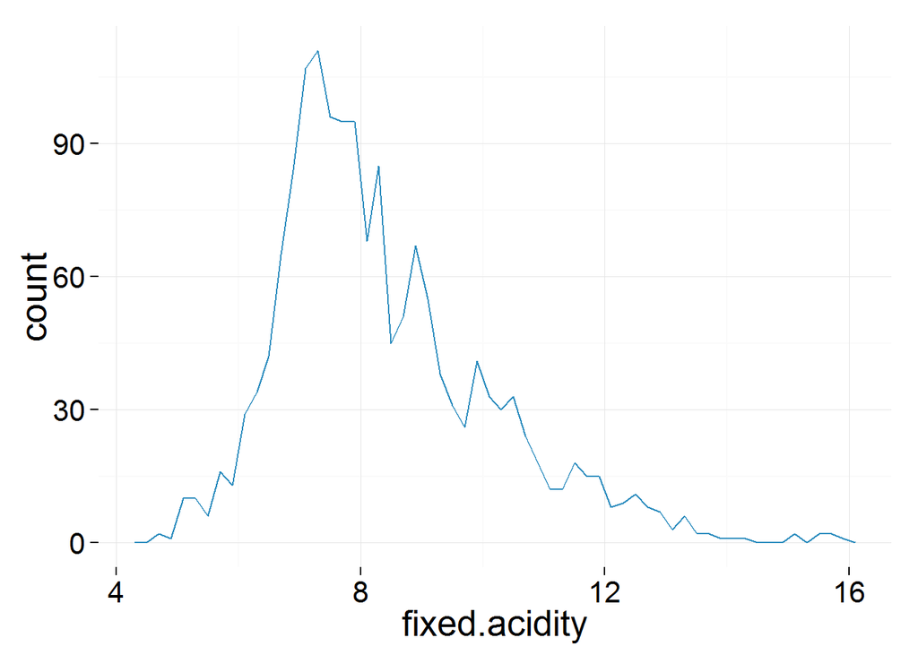

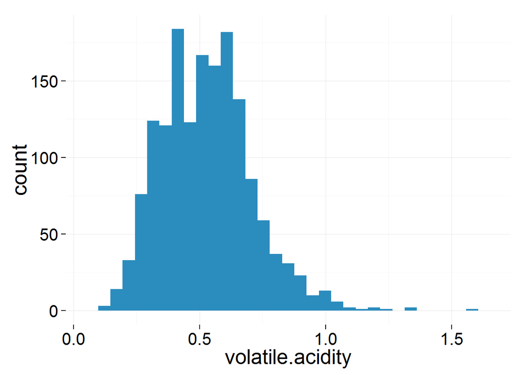

```
##
##  0.6  0.5 0.43 0.59 0.36 0.58
##   47   46   43   39   38   38
```

The volatile acidity histogram shows two peaks around 0.4 and 0.6. The value table shows the peak is at 0.6. It also has some outliers with value greater than 1.5. A further histogram with a smaller bin width(0.02) and the top 1% outliers removed has been plotted.

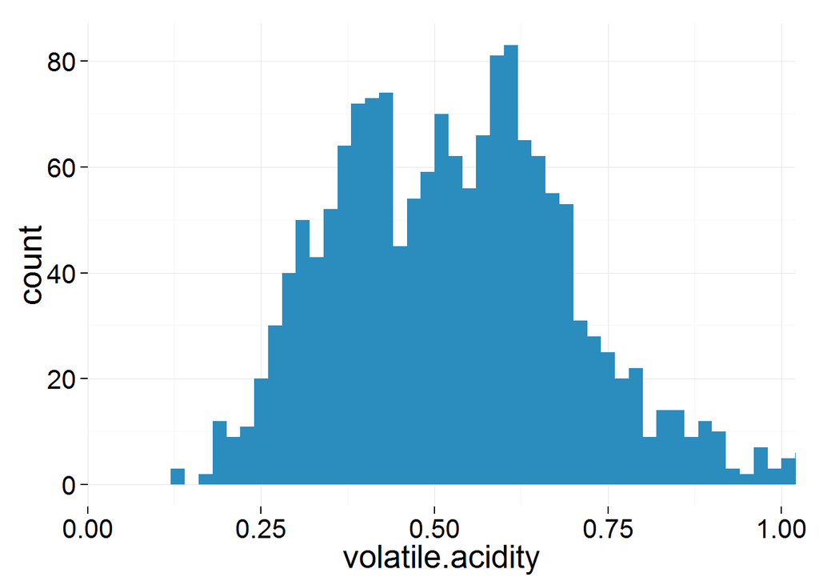

With a smaller bin width, it shows a rather symmetric histogram which seems to be bimodal.

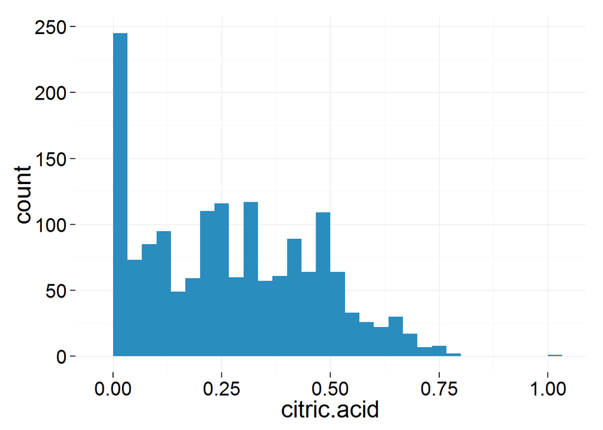

The histogram shows that many samples have zero value of citric acid. A further check on the values shows that there are 132 samples with zero citric acid and 1 outliner sample with a value of 1.0 citric acid. Except the outliner, all of the citric acid values are from 0 to 0.79.

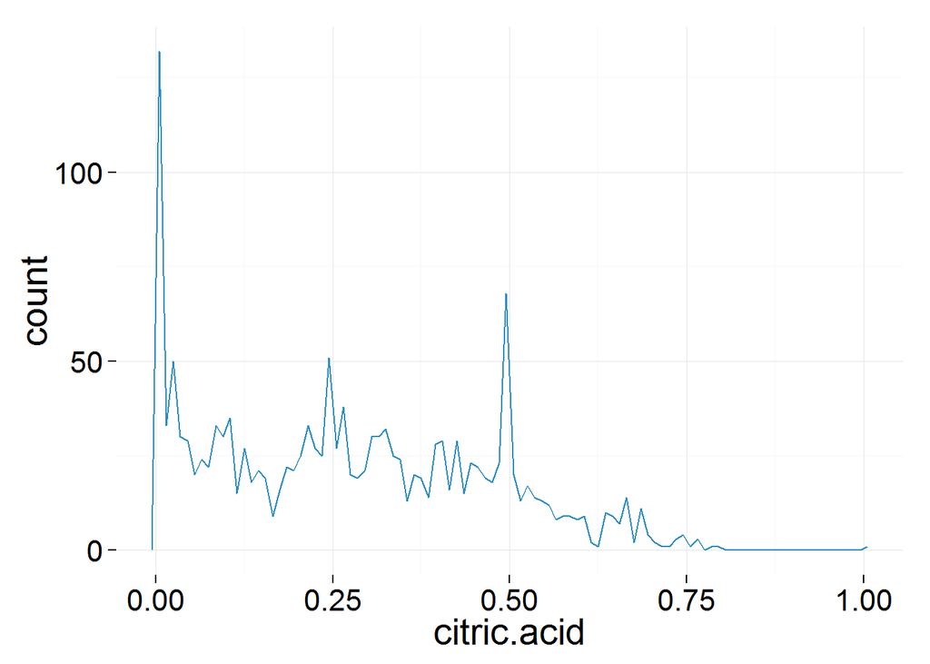

```
##
##    0 0.01 0.02 0.03 0.04 0.05 0.06 0.07 0.08 0.09  0.1 0.11 0.12 0.13 0.14
##  132   33   50   30   29   20   24   22   33   30   35   15   27   18   21
## 0.15 0.16 0.17 0.18 0.19  0.2 0.21 0.22 0.23 0.24 0.25 0.26 0.27 0.28 0.29
##   19    9   16   22   21   25   33   27   25   51   27   38   20   19   21
##  0.3 0.31 0.32 0.33 0.34 0.35 0.36 0.37 0.38 0.39  0.4 0.41 0.42 0.43 0.44
##   30   30   32   25   24   13   20   19   14   28   29   16   29   15   23
## 0.45 0.46 0.47 0.48 0.49  0.5 0.51 0.52 0.53 0.54 0.55 0.56 0.57 0.58 0.59
##   22   19   18   23   68   20   13   17   14   13   12    8    9    9    8
##  0.6 0.61 0.62 0.63 0.64 0.65 0.66 0.67 0.68 0.69  0.7 0.71 0.72 0.73 0.74
##    9    2    1   10    9    7   14    2   11    4    2    1    1    3    4
## 0.75 0.76 0.78 0.79    1
##    1    3    1    1    1
```

A frequency polygon with smaller bin width (0.01) shows similar shape. It is obviously not a normal distribution. There are 3 peaks in the distribution at around 0, 0.25 and 0.5. It seems to be a multimodal distribution.

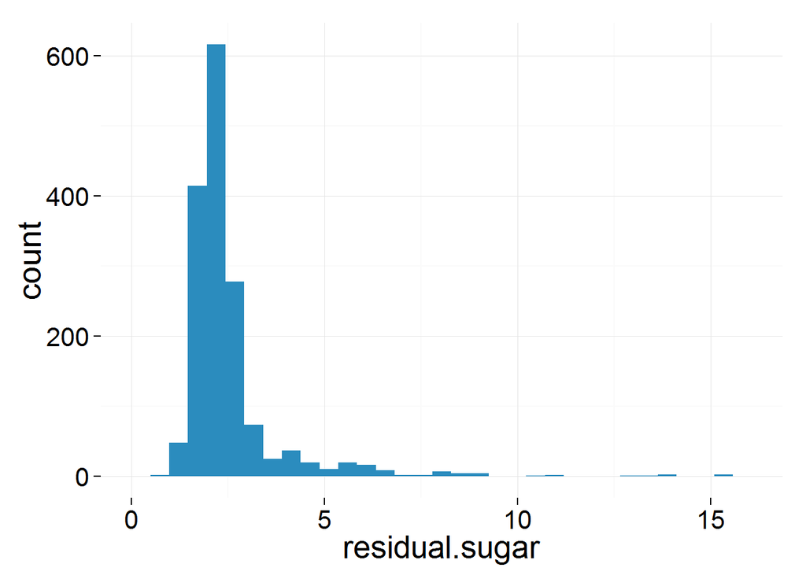

The histogram of residual sugar peaks at around 2.5 with very long tail.

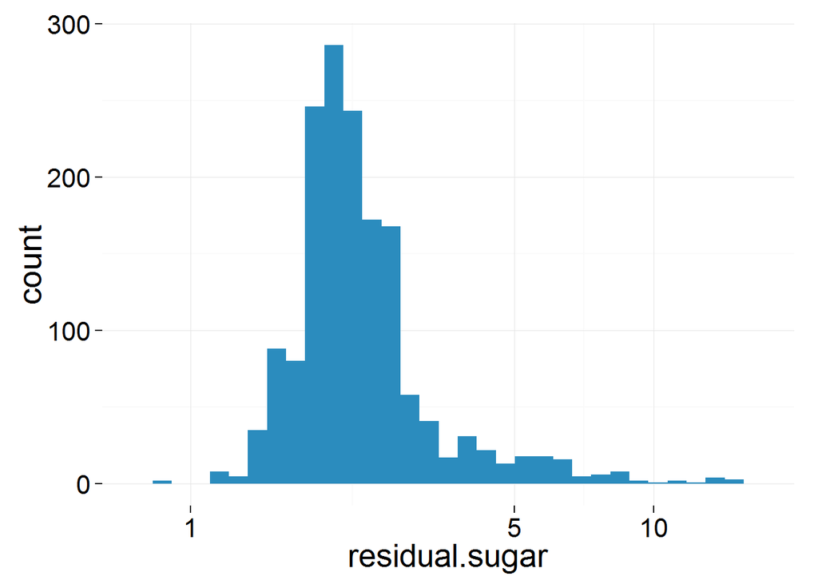

A logarithm transformation shows a skew normal distribution.

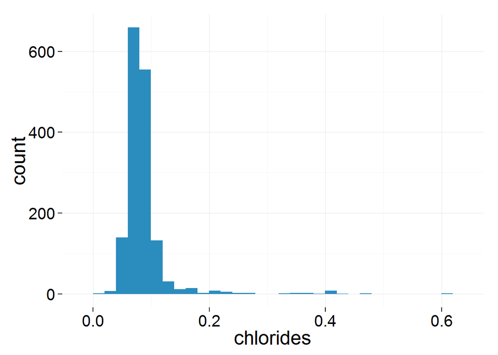

The chlorides histogram is similar to the residual sugar one, a highly skew distribution with long tail. A logarithm transformation shows a nearly normal distribution.

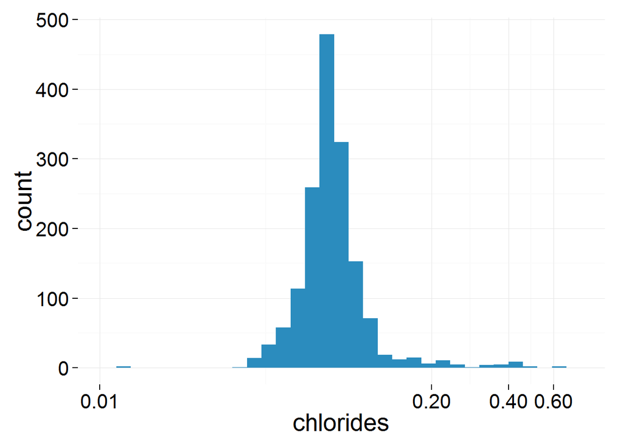

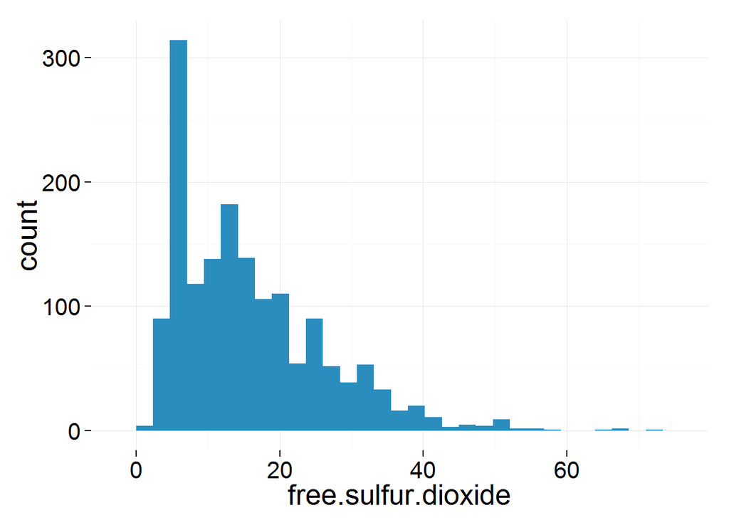

```
##
##   6   5  10  15  12   7
## 138 104  79  78  75  71
```

The free sulfur dioxide shows a peak value at 6. The shape of histogram suggests that the sample number drops gradually along with the increase of free sulfur dioxide. It has a long tail with some outliers.

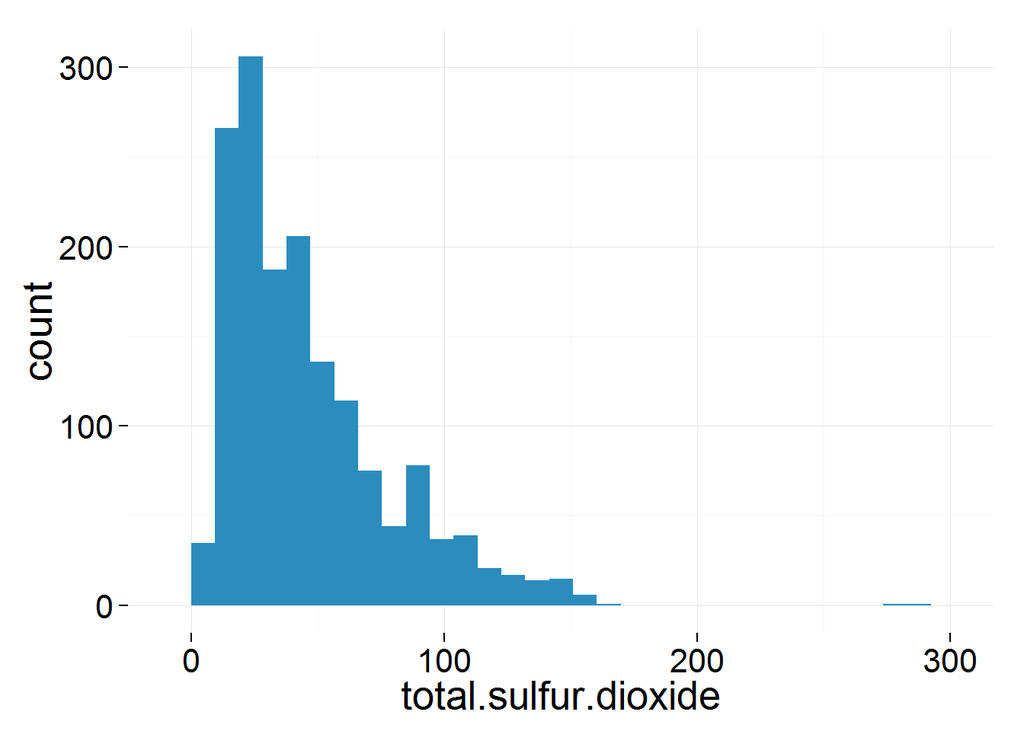

```
##
## 28 24 15 18 23 14
## 43 36 35 35 34 33
```

The total sulfur dioxide shows a similar distribution as the free sulfur dioxide. I suspect that these two variables are correlated. The peak value is at 28. It also has a long tail with some outliers.

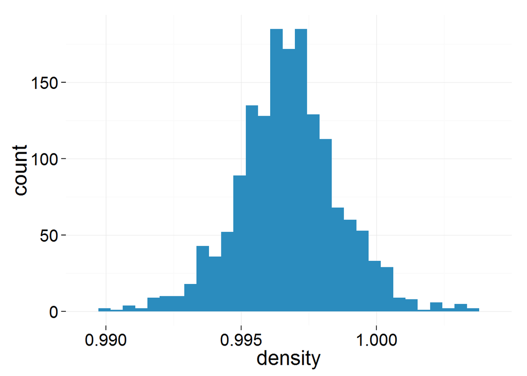

It seems the density plot is a normal distribution. From the summary, the median of density is 0.9968.

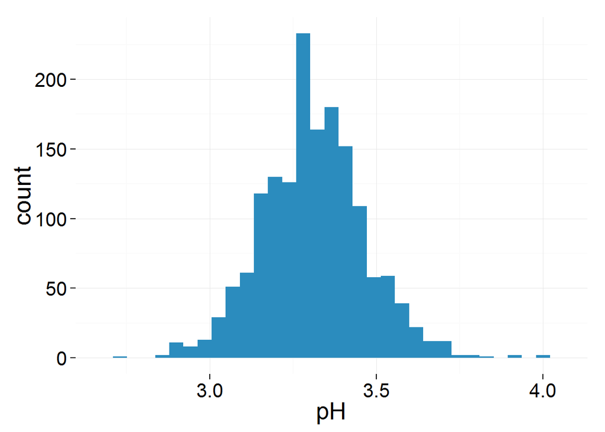

The pH plot is like a normal distribution, with a peak at around 3.3.

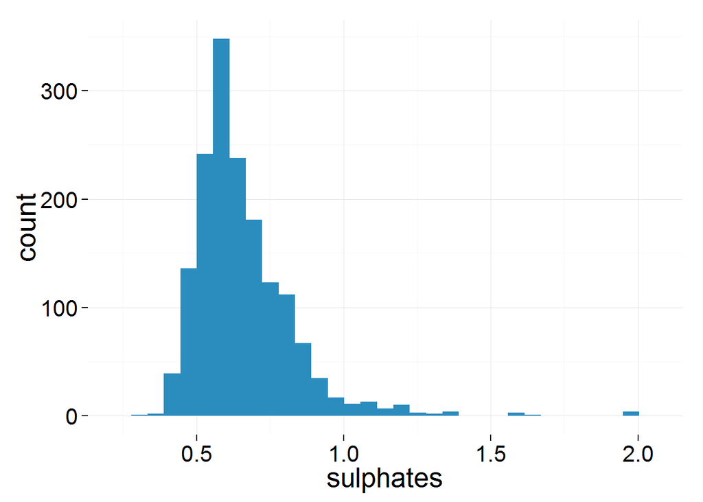

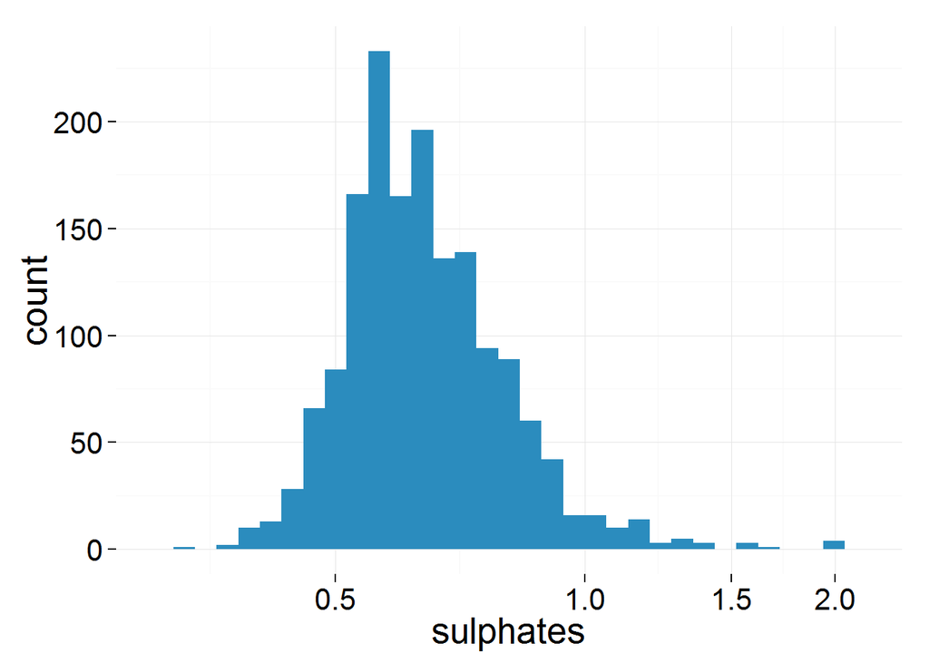

The sulphates plot has some outliers. The peak is at around 0.6. A logarithm transformation shows a normal distribution like histogram.

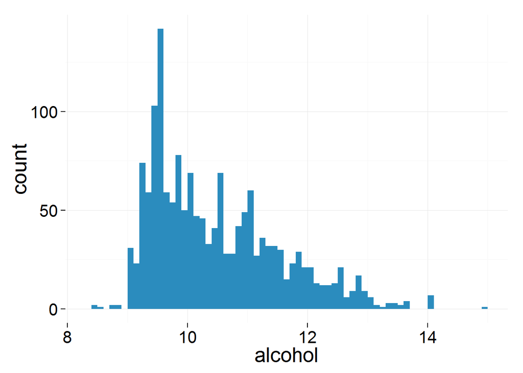

```
##
##  9.5  9.4  9.8  9.2   10 10.5
##  139  103   78   72   67   67
```

The alcohol histogram has a peak at around 9.5. The shape is similar to the free / total sulfur dioxide plots, the number of samples drop evenly along with the increase of alcohol value.

# Univariate Analysis

### What is the structure of your dataset?

There are 1599 wine samples in the dataset with 12 features (fixed.acidity, volatile.acidity, citric.acid, residual.sugar, chlorides, free.sulfur.dioxide, total.sulfur.dioxide, density, pH, sulphates, alcohol, quality). The quality variable is an ordered factor variable ranging from 0 (very bad) to 10 (very excellent).

Other observations:

- More than 80% of wine samples are of quality 5 or 6.
- A large percentage of samples have zero citric acid, and nearly all samples have less than 0.8 gram/liter of citric acid.
- The distributions of density and pH are nearly normal, with mean 0.9967 and 3.3 respectively.
- The distribution of residual sugar, chlorides and sulphates are highly skewed with long tails.

### What is/are the main feature(s) of interest in your dataset?

The main feature of the dataset is the quality. I am interested in finding out what other factors affect the wine quality.

### What other features in the dataset do you think will help support your investigation into your feature(s) of interest?

I am interested in the volatile and citric acid features. I know from the feature description that small quantities of citric acid can add ‘freshness’ and flavor to wines, and high level of volatile acid can lead to unpleasant taste. I also guess that residual sugar, free/total sulfur dioxide and alcohol would affect the wine quality too. These wild guesses can be further verified in bivariate analysis section.

### Did you create any new variables from existing variables in the dataset?

I have created a factor variable for the quality because the original quality variable is numeric. In the dataset, quality should be a categorical variable to indicate the wine ranking. A factor variable would be useful in later bivariate / multivariate analysis.

### Of the features you investigated, were there any unusual distributions? Did you perform any operations on the data to tidy, adjust, or change the form of the data? If so, why did you do this?

I have logarithm transformed the residual sugar, chlorides and sulphates variables which have right skewed distributions and have long tails. A log transformation may reveal their underlying distributions by pulling the outliers closer towards the median.

The result shows that the residual sugar, cholrides and sulphates variables looks like normal distributed after log transformation.

# Bivariate Plots Section

```
##                      fixed.acidity volatile.acidity citric.acid
## fixed.acidity           1.00000000     -0.256130895  0.67170343
## volatile.acidity       -0.25613089      1.000000000 -0.55249568
## citric.acid             0.67170343     -0.552495685  1.00000000
## residual.sugar          0.11477672      0.001917882  0.14357716
## chlorides               0.09370519      0.061297772  0.20382291
## free.sulfur.dioxide    -0.15379419     -0.010503827 -0.06097813
## total.sulfur.dioxide   -0.11318144      0.076470005  0.03553302
## density                 0.66804729      0.022026232  0.36494718
## pH                     -0.68297819      0.234937294 -0.54190414
## sulphates               0.18300566     -0.260986685  0.31277004
## alcohol                -0.06166827     -0.202288027  0.10990325
## quality                 0.12405165     -0.390557780  0.22637251
##                      residual.sugar    chlorides free.sulfur.dioxide
## fixed.acidity           0.114776724  0.093705186        -0.153794193
## volatile.acidity        0.001917882  0.061297772        -0.010503827
## citric.acid             0.143577162  0.203822914        -0.060978129
## residual.sugar          1.000000000  0.055609535         0.187048995
## chlorides               0.055609535  1.000000000         0.005562147
## free.sulfur.dioxide     0.187048995  0.005562147         1.000000000
## total.sulfur.dioxide    0.203027882  0.047400468         0.667666450
## density                 0.355283371  0.200632327        -0.021945831
## pH                     -0.085652422 -0.265026131         0.070377499
## sulphates               0.005527121  0.371260481         0.051657572
## alcohol                 0.042075437 -0.221140545        -0.069408354
## quality                 0.013731637 -0.128906560        -0.050656057
##                      total.sulfur.dioxide     density          pH
## fixed.acidity                 -0.11318144  0.66804729 -0.68297819
## volatile.acidity               0.07647000  0.02202623  0.23493729
## citric.acid                    0.03553302  0.36494718 -0.54190414
## residual.sugar                 0.20302788  0.35528337 -0.08565242
## chlorides                      0.04740047  0.20063233 -0.26502613
## free.sulfur.dioxide            0.66766645 -0.02194583  0.07037750
## total.sulfur.dioxide           1.00000000  0.07126948 -0.06649456
## density                        0.07126948  1.00000000 -0.34169933
## pH                            -0.06649456 -0.34169933  1.00000000
## sulphates                      0.04294684  0.14850641 -0.19664760
## alcohol                       -0.20565394 -0.49617977  0.20563251
## quality                       -0.18510029 -0.17491923 -0.05773139
##                         sulphates     alcohol     quality
## fixed.acidity         0.183005664 -0.06166827  0.12405165
## volatile.acidity     -0.260986685 -0.20228803 -0.39055778
## citric.acid           0.312770044  0.10990325  0.22637251
## residual.sugar        0.005527121  0.04207544  0.01373164
## chlorides             0.371260481 -0.22114054 -0.12890656
## free.sulfur.dioxide   0.051657572 -0.06940835 -0.05065606
## total.sulfur.dioxide  0.042946836 -0.20565394 -0.18510029
## density               0.148506412 -0.49617977 -0.17491923
## pH                   -0.196647602  0.20563251 -0.05773139
## sulphates             1.000000000  0.09359475  0.25139708
## alcohol               0.093594750  1.00000000  0.47616632
## quality               0.251397079  0.47616632  1.00000000
```

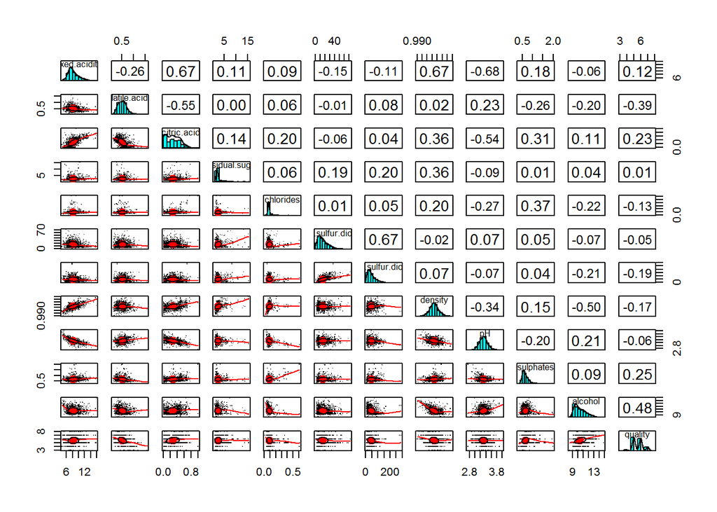

Firstly, I get the pairwise correlations between all features. My main interest is the quality variable. From the result, I know that quality has strongest correlation with alcohol (0.48), volatile acidity (-0.39), sulphates (0.25) and citric acid (0.23).

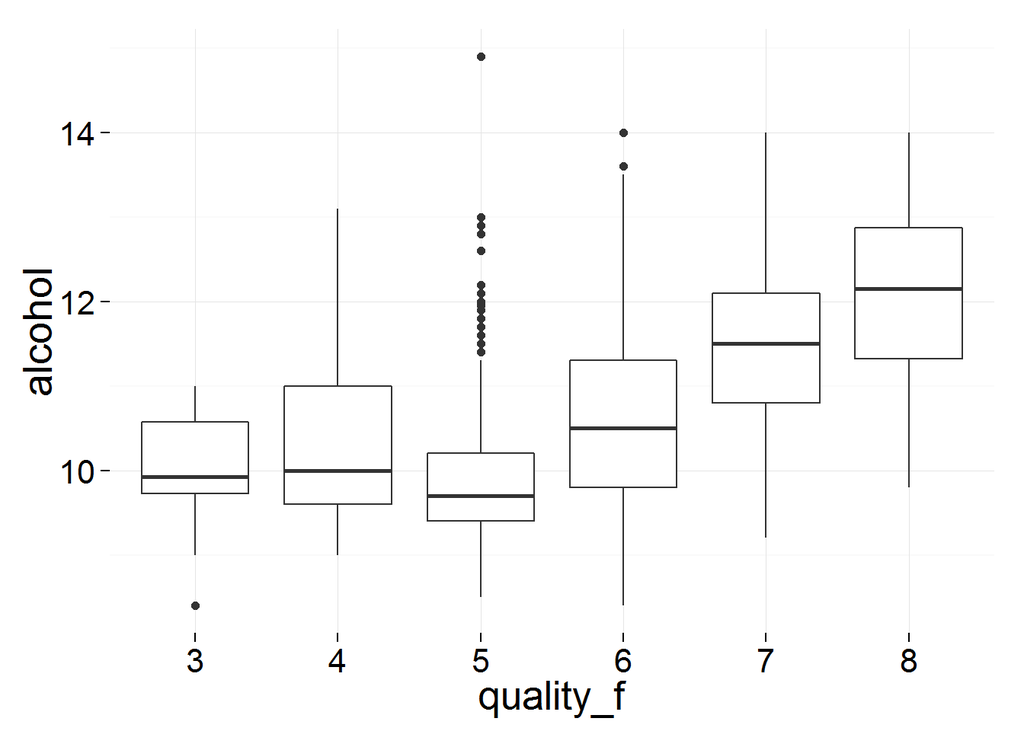

```
## wine$quality: 3
##    Min. 1st Qu.  Median    Mean 3rd Qu.    Max.
##   8.400   9.725   9.925   9.955  10.580  11.000
## --------------------------------------------------------
## wine$quality: 4
##    Min. 1st Qu.  Median    Mean 3rd Qu.    Max.
##    9.00    9.60   10.00   10.27   11.00   13.10
## --------------------------------------------------------
## wine$quality: 5
##    Min. 1st Qu.  Median    Mean 3rd Qu.    Max.
##     8.5     9.4     9.7     9.9    10.2    14.9
## --------------------------------------------------------
## wine$quality: 6
##    Min. 1st Qu.  Median    Mean 3rd Qu.    Max.
##    8.40    9.80   10.50   10.63   11.30   14.00
## --------------------------------------------------------
## wine$quality: 7
##    Min. 1st Qu.  Median    Mean 3rd Qu.    Max.
##    9.20   10.80   11.50   11.47   12.10   14.00
## --------------------------------------------------------
## wine$quality: 8
##    Min. 1st Qu.  Median    Mean 3rd Qu.    Max.
##    9.80   11.32   12.15   12.09   12.88   14.00
```

The boxplot shows that high quality wine tends to have higher alcohol value. The median of alcohol shows an upward trend, except for the samples of quality 5. I can see that quality 5 has more outliers than other samples. It probably implies that there are more sampling errors for those samples of quality 5.

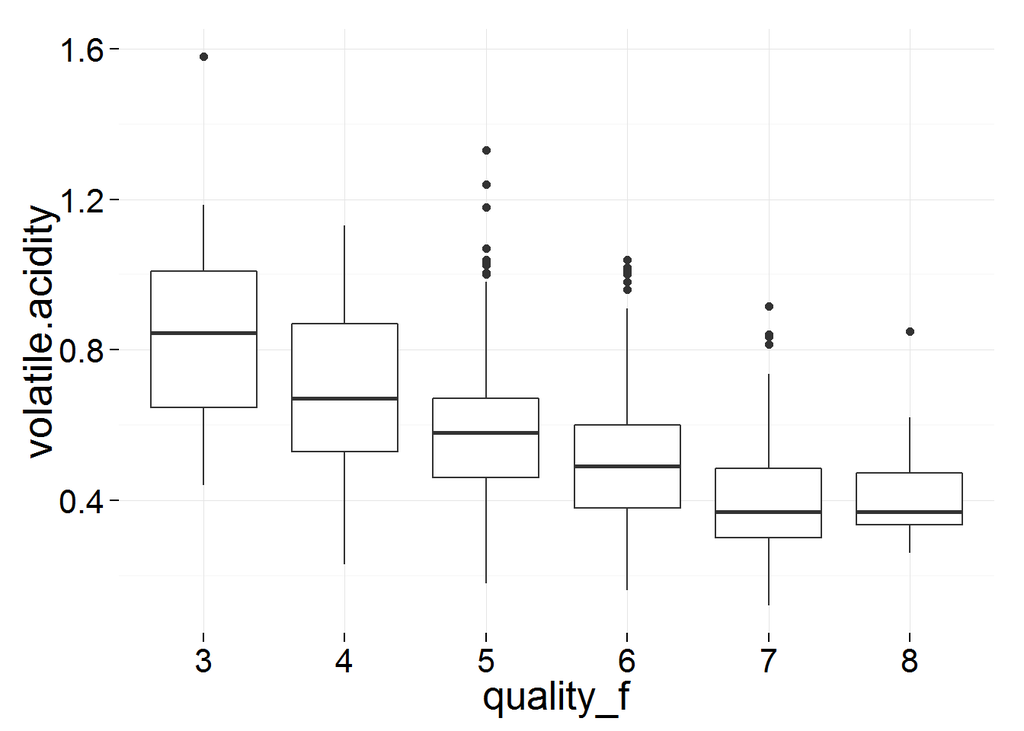

```
## wine$quality: 3
##    Min. 1st Qu.  Median    Mean 3rd Qu.    Max.
##  0.4400  0.6475  0.8450  0.8845  1.0100  1.5800
## --------------------------------------------------------
## wine$quality: 4
##    Min. 1st Qu.  Median    Mean 3rd Qu.    Max.
##   0.230   0.530   0.670   0.694   0.870   1.130
## --------------------------------------------------------
## wine$quality: 5
##    Min. 1st Qu.  Median    Mean 3rd Qu.    Max.
##   0.180   0.460   0.580   0.577   0.670   1.330
## --------------------------------------------------------
## wine$quality: 6
##    Min. 1st Qu.  Median    Mean 3rd Qu.    Max.
##  0.1600  0.3800  0.4900  0.4975  0.6000  1.0400
## --------------------------------------------------------
## wine$quality: 7
##    Min. 1st Qu.  Median    Mean 3rd Qu.    Max.
##  0.1200  0.3000  0.3700  0.4039  0.4850  0.9150
## --------------------------------------------------------
## wine$quality: 8
##    Min. 1st Qu.  Median    Mean 3rd Qu.    Max.
##  0.2600  0.3350  0.3700  0.4233  0.4725  0.8500
```

The boxplot aligns with the negative correlation found in the correlation matrix. It is obvious that the median of the volatile acidity tends to decrease as the quality increases. The difference of volatile acidity between quality 7 and 8 is not obvious. Overall, it aligns with the description of volatile acidity, that high level of it can lead to unpleasant, vinegar taste.

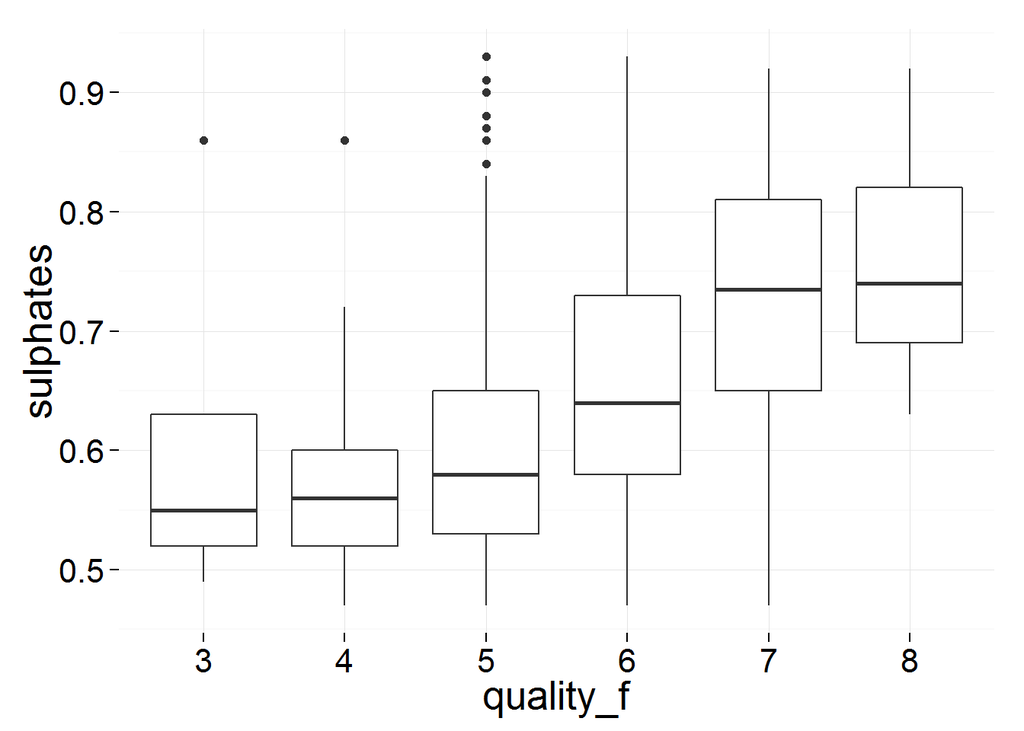

```
## wine$quality: 3
##    Min. 1st Qu.  Median    Mean 3rd Qu.    Max.
##  0.4000  0.5125  0.5450  0.5700  0.6150  0.8600
## --------------------------------------------------------
## wine$quality: 4
##    Min. 1st Qu.  Median    Mean 3rd Qu.    Max.
##  0.3300  0.4900  0.5600  0.5964  0.6000  2.0000
## --------------------------------------------------------
## wine$quality: 5
##    Min. 1st Qu.  Median    Mean 3rd Qu.    Max.
##   0.370   0.530   0.580   0.621   0.660   1.980
## --------------------------------------------------------
## wine$quality: 6
##    Min. 1st Qu.  Median    Mean 3rd Qu.    Max.
##  0.4000  0.5800  0.6400  0.6753  0.7500  1.9500
## --------------------------------------------------------
## wine$quality: 7
##    Min. 1st Qu.  Median    Mean 3rd Qu.    Max.
##  0.3900  0.6500  0.7400  0.7413  0.8300  1.3600
## --------------------------------------------------------
## wine$quality: 8
##    Min. 1st Qu.  Median    Mean 3rd Qu.    Max.
##  0.6300  0.6900  0.7400  0.7678  0.8200  1.1000
```

From the boxplot, it seems that the sulphates variable also has a positive correlation with the quality. The median of sulphates increases with the quality for samples. However, I cannot deduce that it is a meaningful correlation because there are many outliers with large values for quality 5 and 6. The high correlation value may be due to sampling error? I think even sulphates may affect the quality, it should not be an important factor.

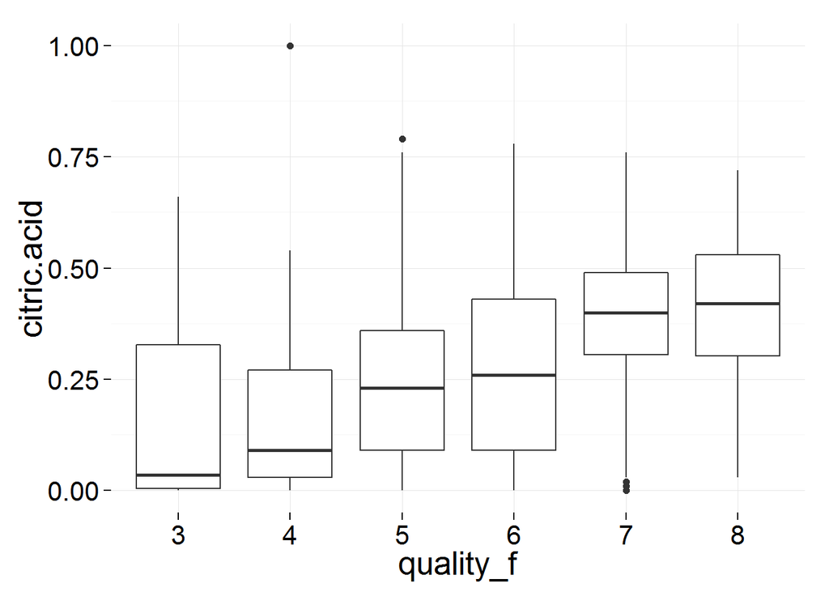

```
## wine$quality: 3
##    Min. 1st Qu.  Median    Mean 3rd Qu.    Max.
##  0.0000  0.0050  0.0350  0.1710  0.3275  0.6600
## --------------------------------------------------------
## wine$quality: 4
##    Min. 1st Qu.  Median    Mean 3rd Qu.    Max.
##  0.0000  0.0300  0.0900  0.1742  0.2700  1.0000
## --------------------------------------------------------
## wine$quality: 5
##    Min. 1st Qu.  Median    Mean 3rd Qu.    Max.
##  0.0000  0.0900  0.2300  0.2437  0.3600  0.7900
## --------------------------------------------------------
## wine$quality: 6
##    Min. 1st Qu.  Median    Mean 3rd Qu.    Max.
##  0.0000  0.0900  0.2600  0.2738  0.4300  0.7800
## --------------------------------------------------------
## wine$quality: 7
##    Min. 1st Qu.  Median    Mean 3rd Qu.    Max.
##  0.0000  0.3050  0.4000  0.3752  0.4900  0.7600
## --------------------------------------------------------
## wine$quality: 8
##    Min. 1st Qu.  Median    Mean 3rd Qu.    Max.
##  0.0300  0.3025  0.4200  0.3911  0.5300  0.7200
```

The citric acid boxplot looks interesting. Although the correlation coefficient between citric acid and quality is only about 0.23, the boxplot does show an interesting pattern. The median of citric acid tends to increase as the wine quality increases. Moreover, it seems there are different levels of medians. The medians for quality 3/4 are close to each other, same as quality 5/6 and 7/8. Interestingly, the univariate analysis shows a multimodal distribution of the citric acid variable, with peaks at 0, 0.25 and 0.5.

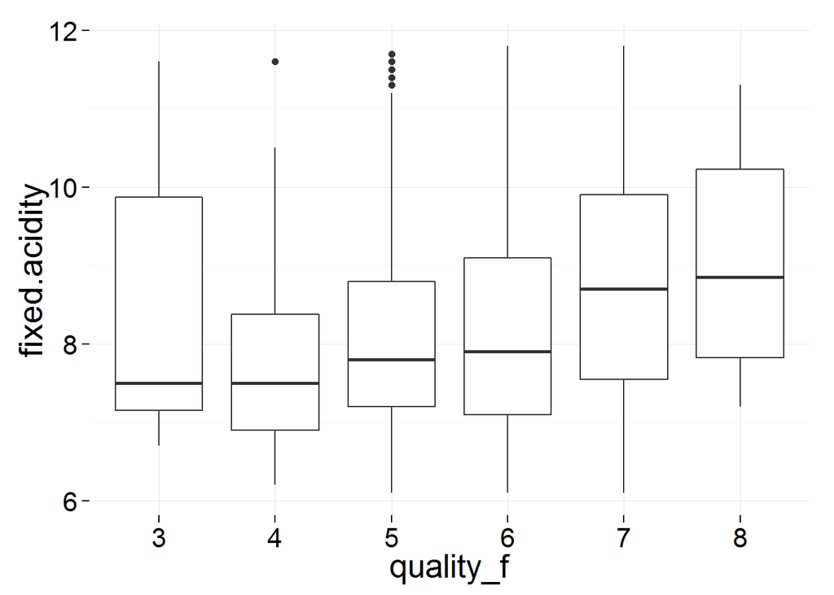

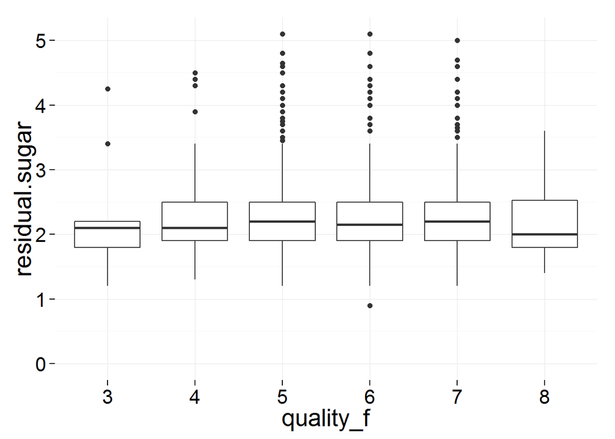

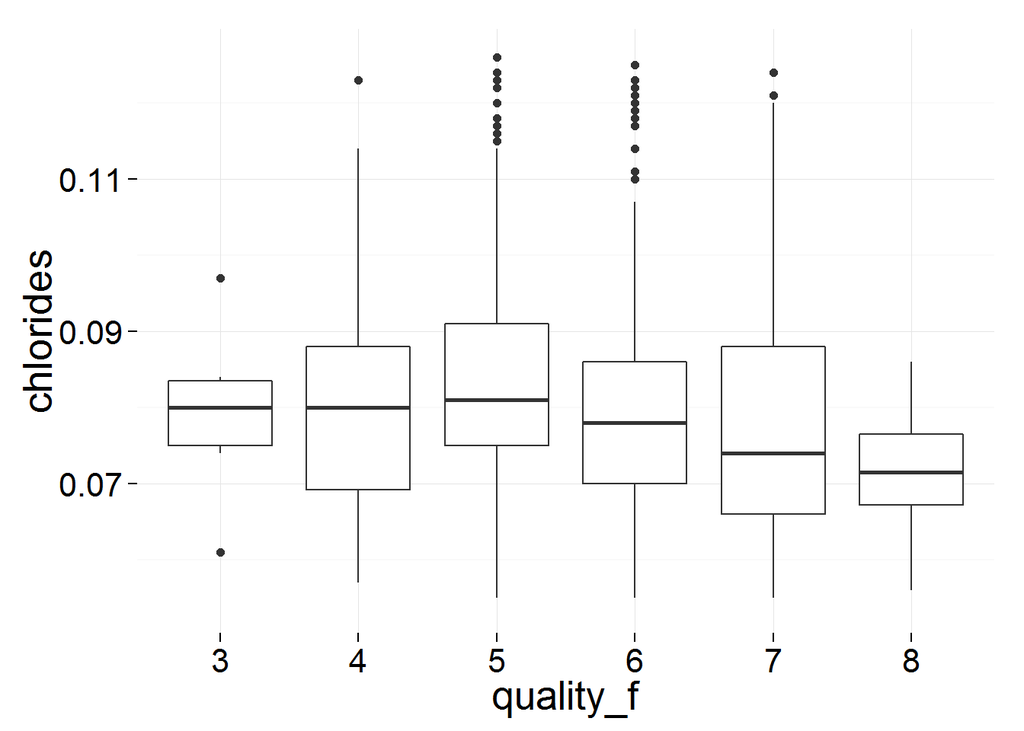

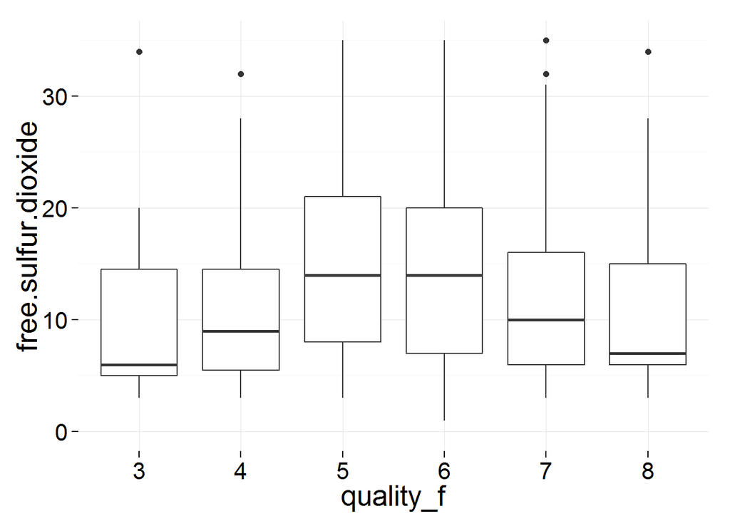

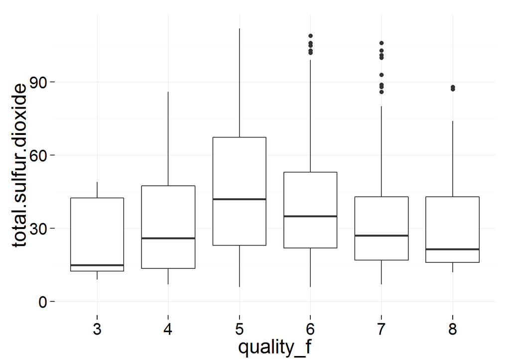

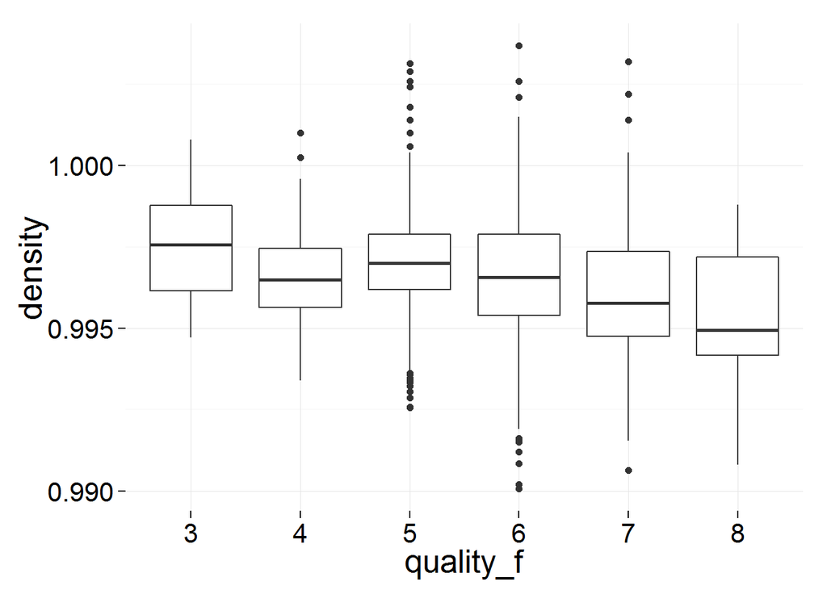

[output not shown]

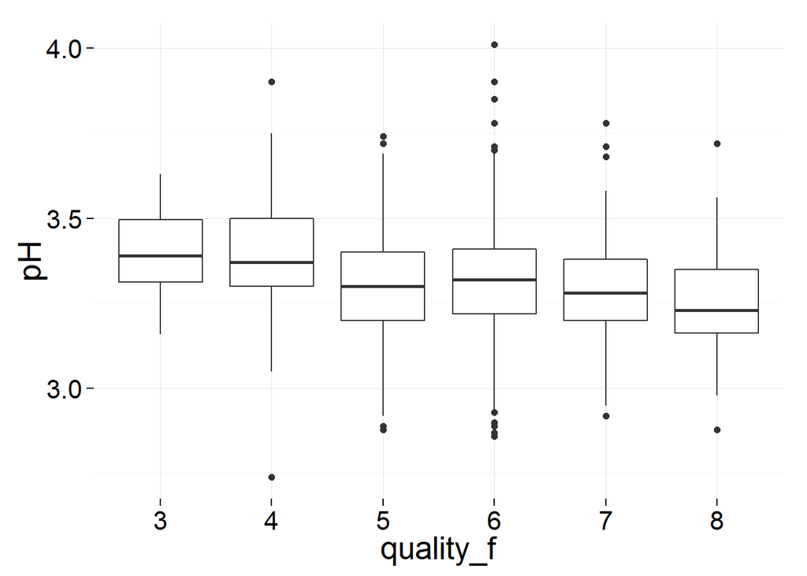

[output not shown]

Most of the other features do not show an obvious correlation with quality, except density and pH.

It is found that wine with good quality (7 and 8) have lower density and pH median values than other quality.

From the correlation matrix, I can see the following strong correlations for non-quality variables:

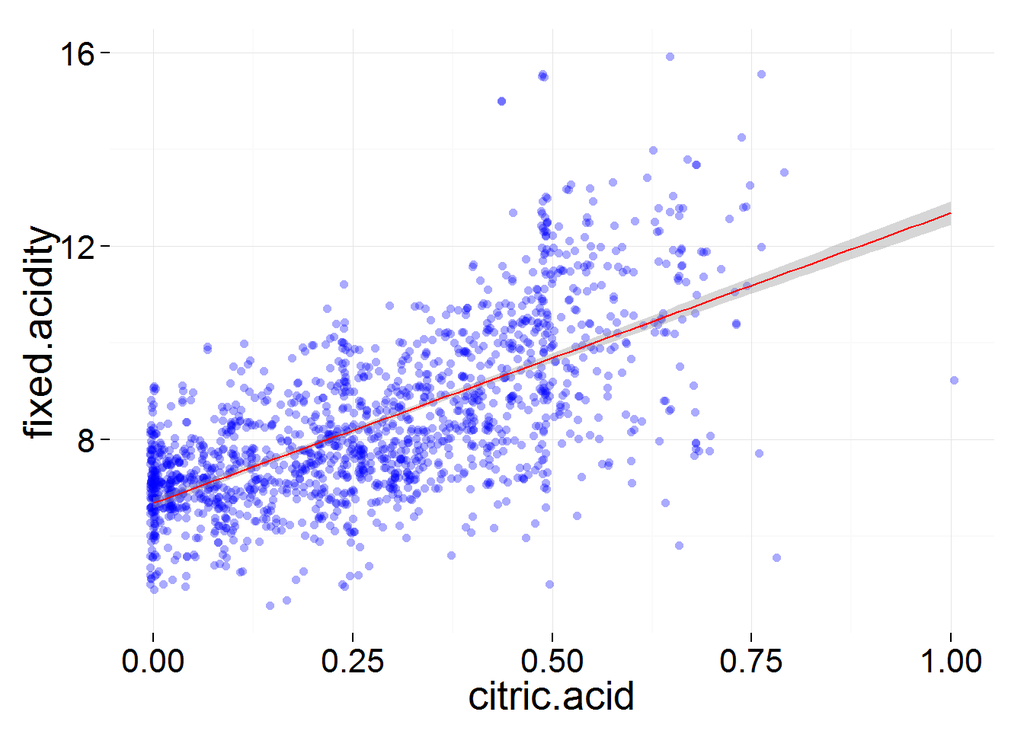

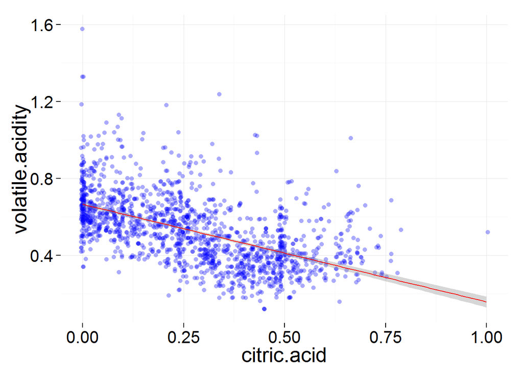

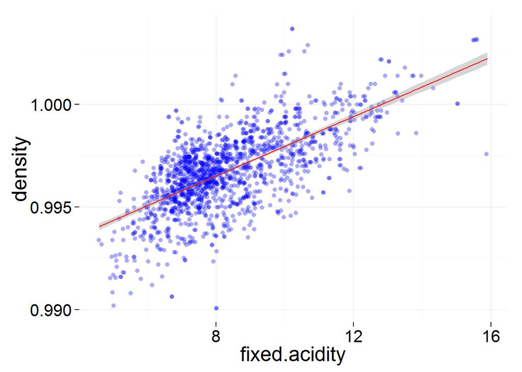

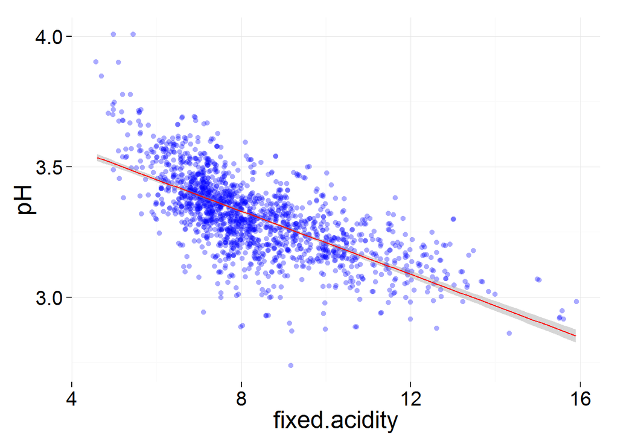

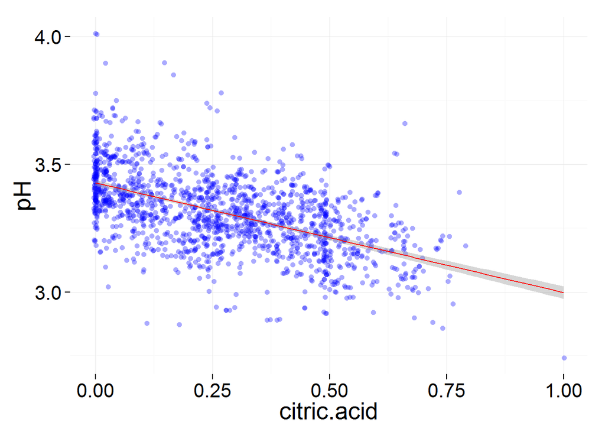

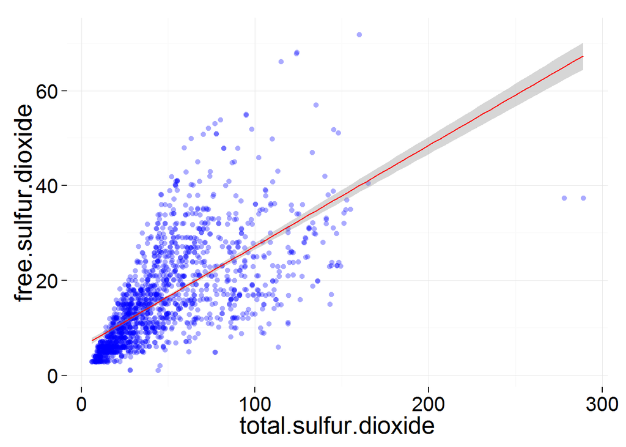

The scatterplots show clearly that fixed acidity and citric acid have positive strong correlation, i.e. when one increases, another tends to increase, and vice versa. Volatile acidity, on the other hand, has a negative correlation with citric acid, i.e. when one increases, another one tends to decrease.

The pH value tends to decrease when fixed acidity or citric acid increases, which does make sense as I think it is straight forward that pH and acidity have negative correlation.

The correlation between free and total sulfur dioxide should be a straight forward one. From my understanding, the amount of total sulfur dixoide should include the free sulfur dioxide, and I expect that when the total sulfur dioxide increases, a part of it should contain (or be converted to) free sulfur dioxide.

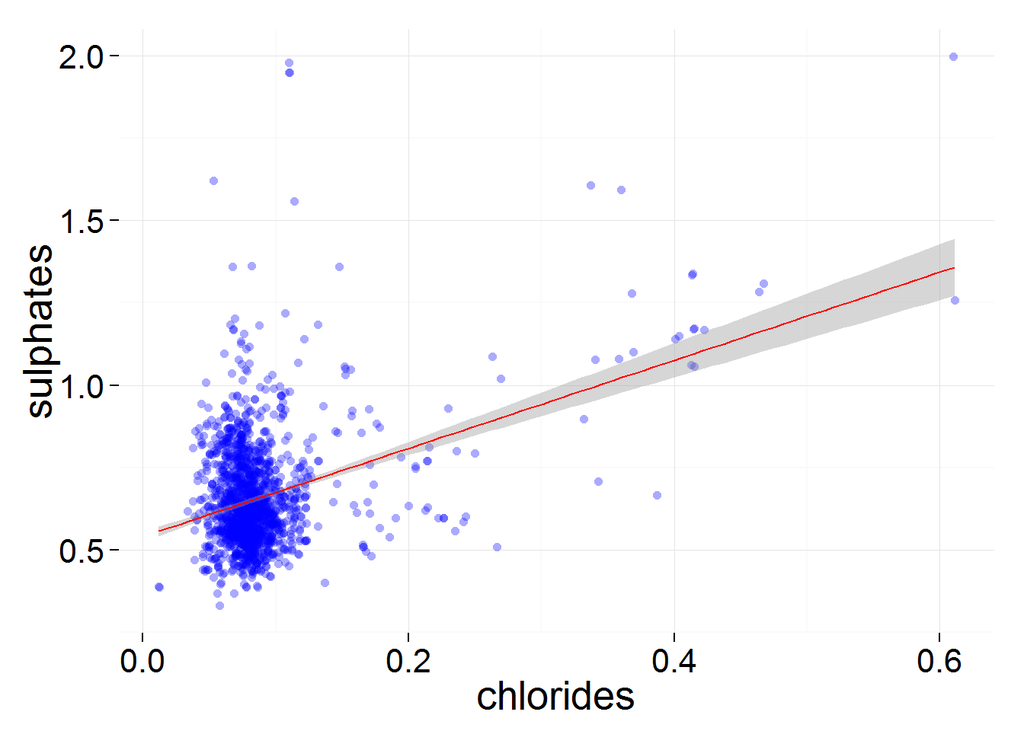

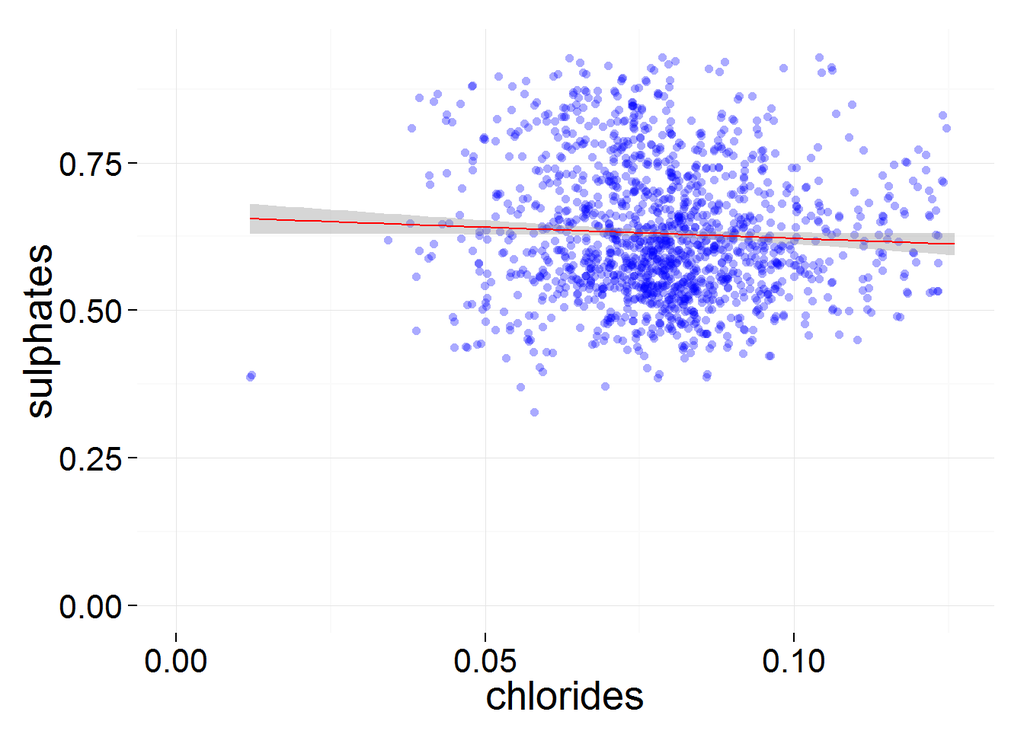

```
##
##  Pearson's product-moment correlation
##
## data:  chlorides and sulphates
## t = -2.0202, df = 1466, p-value = 0.04354
## alternative hypothesis: true correlation is not equal to 0
## 95 percent confidence interval:
##  -0.103573750 -0.001532528
## sample estimates:
##         cor
## -0.05269068
```

I also observed that a high correlation value does not necessarily guarantee a real correlation. For example, the correlation of chlorides and sulphates is 0.37. However, when I remove the top 5% outliers for both variables, the correlation drops dramatically to -0.05.

# Bivariate Analysis

### Talk about some of the relationships you observed in this part of the investigation. How did the feature(s) of interest vary with other features in the dataset?

Quality strongly correlates with alcohol (0.48), volatile acidity (-0.39), sulphates (0.25) and citric acid (0.23).

Good quality wine tends to have higher alcohol value.

Good quality wine tends to have lower volatile acidity. It aligns with the observation that high level of volatile acidity can lead to unpleasant, vinegar taste (i.e. worse quality).

The quality seems to have a positive correlation with sulphates, but this correlation is not obvious as there are many outliers for quality 5.

Bad quality (3 or 4) wine tends to have little or zero citric acid. Average quality (5 or 6) wine tends to have roughly 0.25 g/dm^3 citric acid. Good quality (7 or 8) wine tends to have more than 0.25 g/dm^3 citric acid.

Good quality wine tends to have low density and pH value.

### Did you observe any interesting relationships between the other features (not the main feature(s) of interest)?

The correlation between fixed acidity, volatile acidity and citric acid is interesting. High fixed acidity implies higher value of citric acid, and higher citric acid value tends to give better wine quality. On the other hand, volatile acidity negatively correlates with both fixed acidity, and bad quality wine tends to have high volatile acidity.

### What was the strongest relationship you found?

The quality variable has the strongest relationship with the alcohol variable. From the boxplot, it is obvious that good quality wine has higher value of alcohol.

# Multivariate Plots Section

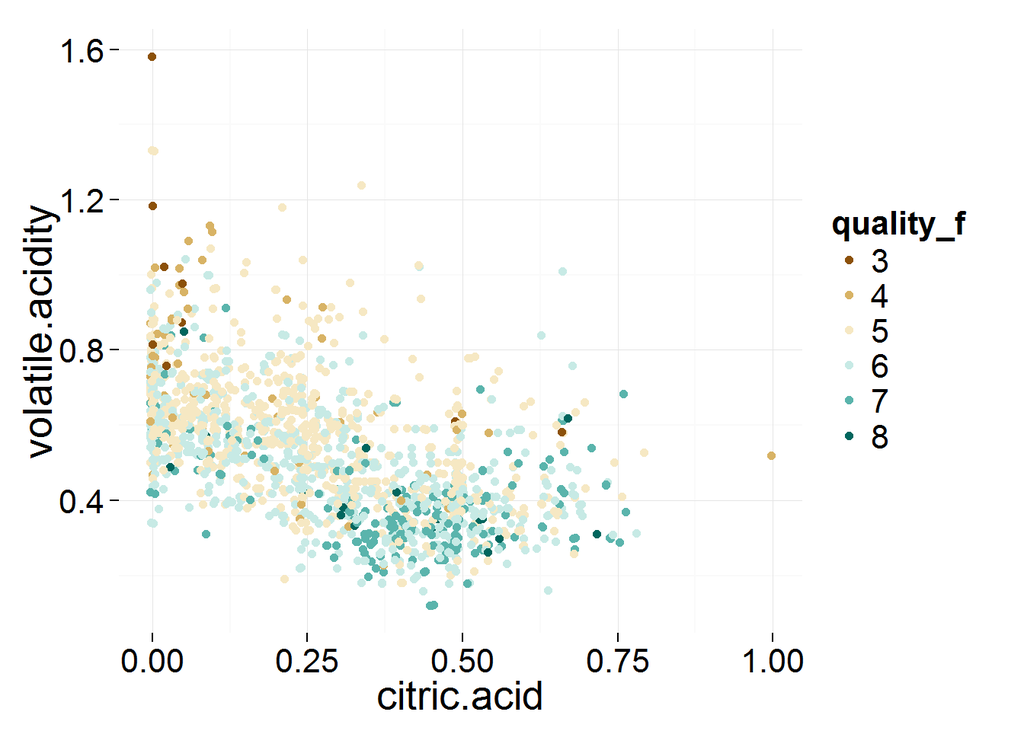

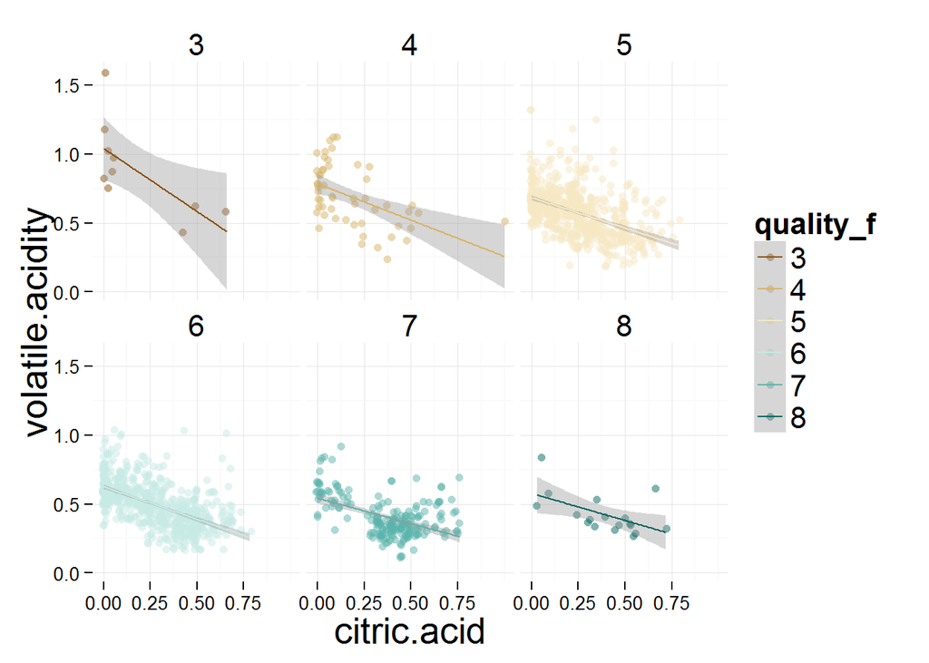

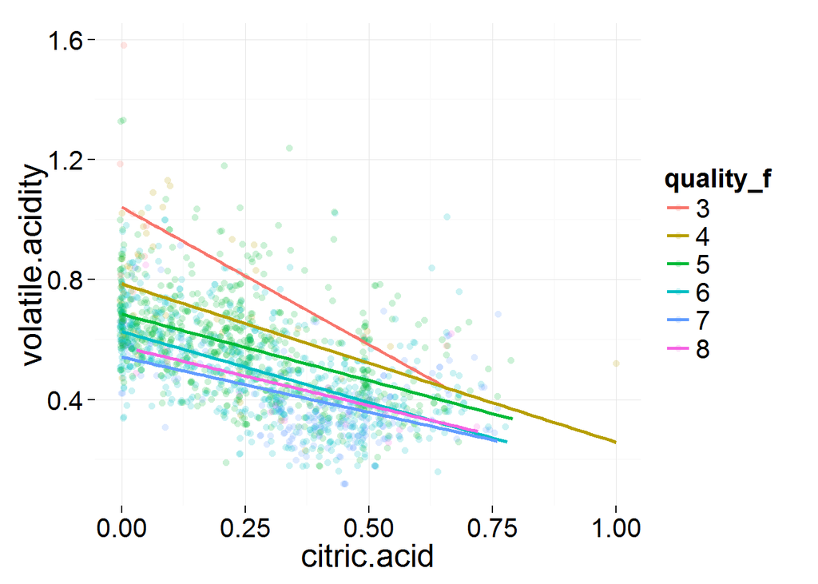

The plots explain the relationship between citric acid and volatile acidity for different wine quality. For each quality category, the citric acid negatively correlates with volatile acidity. From the last plot, it can be seen that the linear regressions for different quality categories are different by some offset. I think the implications are:

- Better quality wine has lower volatile acidity
- The correlation between citric acid and volatile is negative for every wine quality level

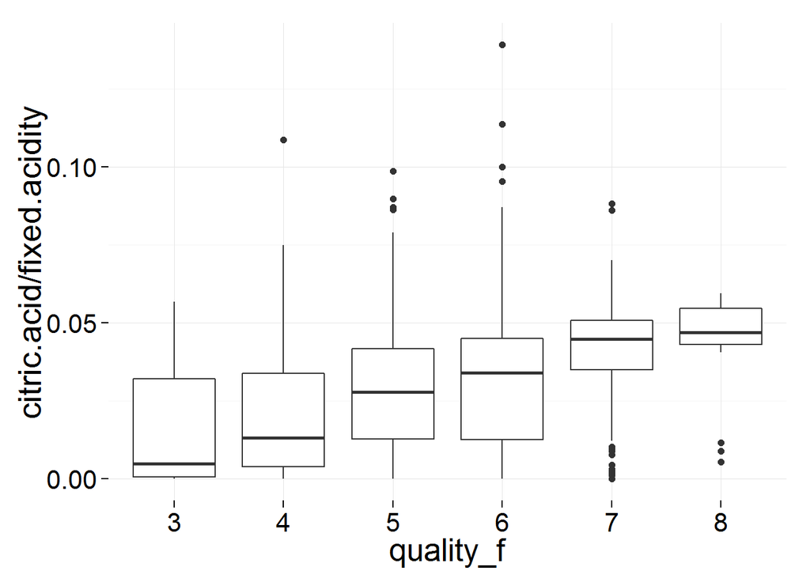

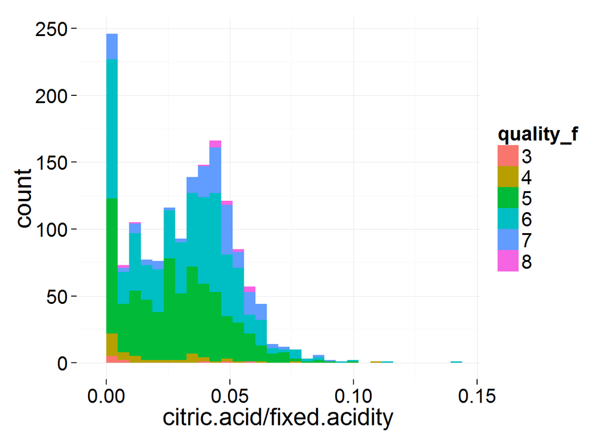

Rather than the absolute amount of citric acid, I am also interested in the ratio of citric acid to fixed acidity. The median of this ratio for good quality wine is close to 0.05. The histogram also shows that there are more good wine samples (quality 7) in the bins around 0.05.

# Multivariate Analysis

### Talk about some of the relationships you observed in this part of the investigation. Were there features that strengthened each other in terms of looking at your feature(s) of interest?

The relationship of citric acid and volatile acidity is further strengthened by looking at their correlation under different quality categories. The citric acid variable negatively correlates with volatile acidity for all kinds of quality. Linear models using citric acid and volatile acidity can be used to predict the quality of wine.

### Were there any interesting or surprising interactions between features?

The citric acid to fixed acidity ratio seems to be a good indicator for the wine quality. When the ratio is close to 0.05, there is higher proportion of good quality wine.

# Final Plots and Summary

### Plot One

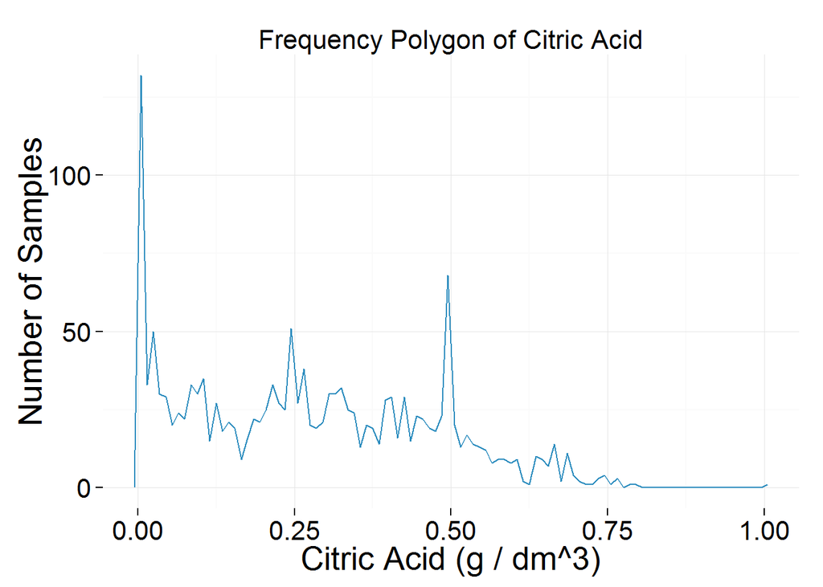

### Description One

The distribution of citric acid seems multimodal. There are 3 local peaks in the distribution at around 0, 0.25 and 0.5. There is a large number of the wine samples having zero citric acid.

### Plot Two

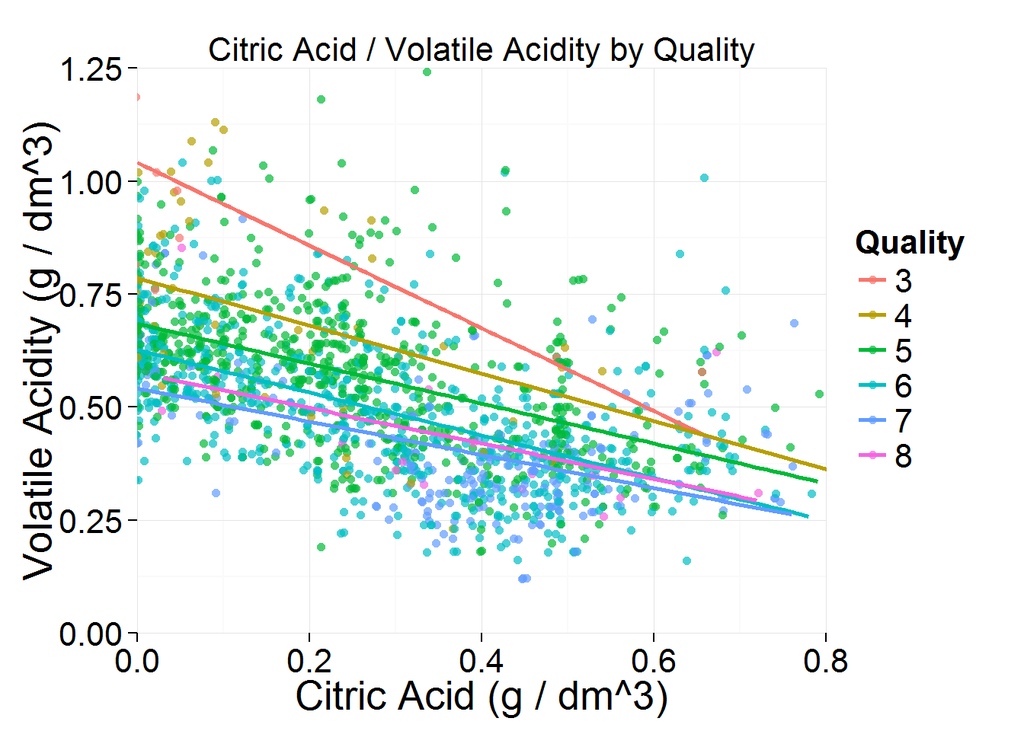

### Description Two

Wine with good quality tends to have higher citric acid and lower volatile acidity. Citric acid and volatile acidity negatively correlate to each other. A possible explanation is that citric acid could be tranformed to volatile acidity (or vice versa) under certain conditions.

### Plot Three

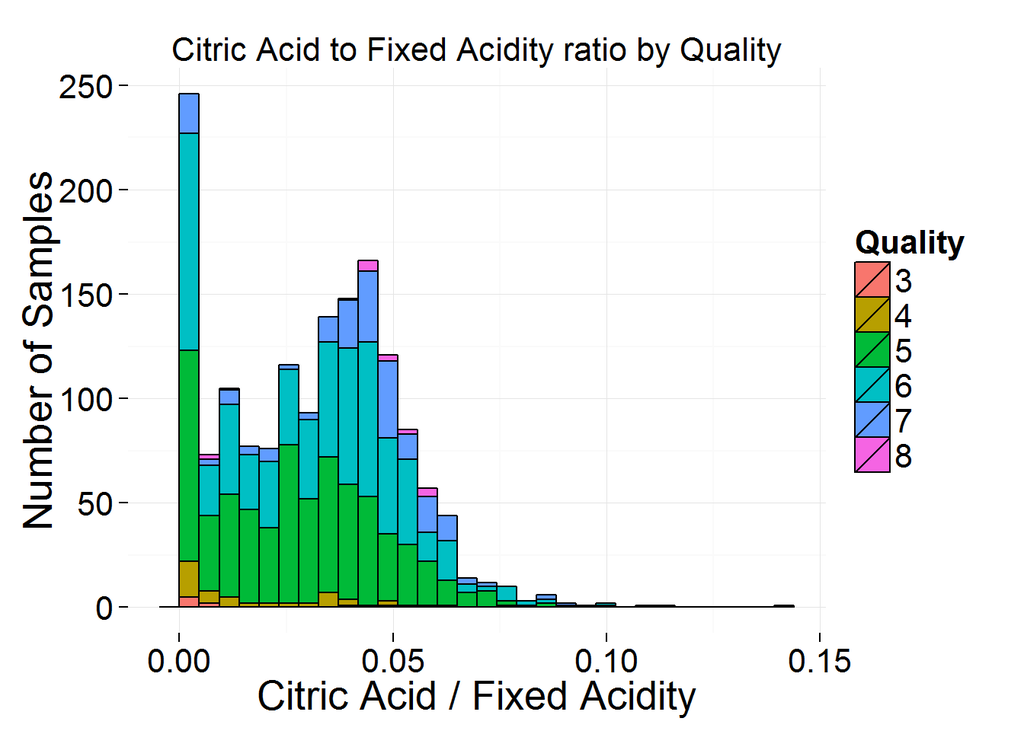

### Description Three

The proportion of good quality wine samples increases when the amount of citric acid is close to 5% of the fixed acidity. It also shows that the number of samples starts to drop when the ratio is greater than 0.05.

# Reflection

The dataset contains 1599 samples of red wine from 2009. First I examined the histograms of all individual variables in order to find out their distributions. For some variables I can see some interesting distribution, like the multimodal distribution of citric acid. To further explore the relationship between all variables to the quality variable which is my main interest, I found out the pairwise correlation coefficients of all variables. Several variables had been identified to have strong correlation with quality, which were Alcohol, Volatile Acidity, Sulphates and Citric Acid. I examined the box plots of those variables against the quality. I think that the citric acid was an interesting variable due to its multimodal behavior, so I decided to give it a more detailed look. I mainly focused on the relationship between citric acid, fixed acidity and volatile acidity. Finally I made some conclusions about the ratio of citric acid to fixed acidity, and the negative correlation of citric acid and volatile acidity. I think one of the main difficulties for this analysis was the limited number of good or bad samples, which is less than 20% of the total count. Also it seems to me that the quality range (i.e. 3 to 8) in the samples was not large enough to derive an accurate prediction. Perhaps it was the limitation of measurement by human experts, which was very subjective. I think one future work for this dataset would be to apply some inferential statistics to strengthen the findings. For example, to setup hypothesis testing to verify the relationship between some variables and the quality (e.g. the citric acid ratio).